# **Analysis of Trends in Bachelor's Degrees Conferred by Postsecondary Institutions**

Spring 2025 Data Science Project  
Maheen Gul, Thomas Nguyen

### **Contributions by Maheen Gul**

A. Project idea  
B. Dataset Curation and Preprocessing  
C. Data Exploration and Summary Statistics  
E: ML Algorithm Training and Test Data Analysis  
F: Conclusion

Maheen contributed to the project creation and organization, exploratory data analysis with Thomas, training and testing the machine learning model, and writing the conclusion.

### **Contributions by Thomas Nguyen**

C. Data Exploration and Summary Statistics  
D: ML Algorithm Design/Development  
F: Visualization, Result Analysis  
G: Final Tutorial Report Creation

Thomas contributed to the exploratory data analysis with Maheen, choosing the machine learning algorithm to answer our questions, creating the insightful visualizations, and helping with finalizing the report.

1. Introduction
2. Data Curation
3. Exploratory Data Analysis
4. Primary Analysis
5. Visualization
6. Insights and Conclusions

## **Introduction**

**What is our topic?**

We are interested in analyzing the trends in bachelor’s degrees conferred to undergraduate students by postsecondary institutions across the United States during the 2010-11 to 2022-23 academic years.

**What question(s) are we trying to answer with our analysis?**

1. What are the trends in bachelor's degrees granted to undergraduate students?
2. Is Computer Science the trend, meaning is it the most popular field of study among undergraduate students?
3. Is Computer Science a popular field of study among women in comparison to men?

**Why is answering those questions important?**

Based on our time at the University of Maryland, Computer Science and other STEM-related subjects appear to have become in demand among students in recent years. The demand has increased so much that certain majors like Computer Science have become limited enrollment programs. We want to analyze the data to determine whether this is true across the United States and consider what could be the reason behind this trend.

## **Data Curation**

The dataset for our project is sourced from the [U.S. Department of Education](https://nces.ed.gov/ipeds/SummaryTables/report/360?templateId=3601&year=2023&expand_by=1&tt=aggregate&instType=1&sid=175d7267-df04-4288-8edd-23c2ec8c831b), National Center for Education Statistics, Integrated Postsecondary Education Data System (IPEDS), Completions component. The dataset is about the completion of degrees by undergraduate students across the United States during the academic years 2010-11 to 2022-23. The data includes the title of the degrees, the total number of degrees conferred for each title, the number of degrees conferred to women and men for each title, and the academic year.

```python
# libraries to import
import pandas as pd
import numpy as np
import matplotlib.pyplot as plt
import seaborn as sns
from sklearn.cluster import KMeans
from sklearn.preprocessing import StandardScaler
```

```python
# organizing dataframe
df = pd.read_csv("SummaryTables-2010-2023.csv")
```

```python
# datapoints and features in df
df.shape
```

```
(494, 8)
```

```python
# names of all the features in df
df.columns
```

```
Index(['Unnamed: 0', 'Award Level', 'CIP Title', 'CIP Code', 'Total', 'Men',
       'Women', 'Academic Year'],
      dtype='object')
```

```python
# we don't need all the features, we can disregard the first two columns
df = df[["CIP Title", "CIP Code", "Total", "Men", "Women", "Academic Year"]]
```

```python
# data types of all the features in df
df.dtypes
```

|  | 0 |
| --- | --- |
| CIP Title | object |
| CIP Code | int64 |
| Total | object |
| Men | object |
| Women | object |
| Academic Year | object |

**dtype:** object

```python
# convert data type of total, men, and women columns to int for analysis
df["Total"] = df["Total"].str.replace(",", "").astype(int)
df["Men"] = df["Men"].str.replace(",", "").astype(int)
df["Women"] = df["Women"].str.replace(",", "").astype(int)
```

```python
# data type of total, men, and women columns should be int now
df.dtypes
```

|  | 0 |
| --- | --- |
| CIP Title | object |
| CIP Code | int64 |
| Total | int64 |
| Men | int64 |
| Women | int64 |
| Academic Year | object |

**dtype:** object

```python
# display dataframe
df
```

|  | CIP Title | CIP Code | Total | Men | Women | Academic Year |
| --- | --- | --- | --- | --- | --- | --- |
| 0 | Agriculture, Agriculture Operations and Relate... | 1 | 28709 | 15324 | 13385 | 2010-11 |
| 1 | Natural Resources and Conservation | 3 | 19160 | 10670 | 8490 | 2010-11 |
| 2 | Architecture and Related Services | 4 | 18870 | 10659 | 8211 | 2010-11 |
| 3 | Area, Ethnic, Cultural, Gender, and Group Studies | 5 | 12227 | 3895 | 8332 | 2010-11 |
| 4 | Communication, Journalism, and Related Programs | 9 | 96860 | 34403 | 62457 | 2010-11 |
| ... | ... | ... | ... | ... | ... | ... |
| 489 | Transportation and Materials Moving | 49 | 23297 | 19656 | 3641 | 2022-23 |
| 490 | Visual and Performing Arts | 50 | 142964 | 53666 | 89298 | 2022-23 |
| 491 | Health Professions and Related Programs | 51 | 881691 | 160239 | 721452 | 2022-23 |
| 492 | Business, Management, Marketing, and Related S... | 52 | 791675 | 390298 | 401377 | 2022-23 |
| 493 | History | 54 | 28549 | 16599 | 11950 | 2022-23 |

494 rows × 6 columns

## **Exploratory Data Analysis**

Our first objective is to see the trends in fields of study, more specifically in Computer Science, by analyzing the dataset. If we look at the University of Maryland in recent years, Computer Science has become such a popular program among undergraduates that it has become a limited enrollment program. We want to see if this is true across the nation.

In our exploratory data analysis, we will do the following statistical tests:

1. **Hypothesis Test with ANOVA:** Test whether or not Computer Science is the most popular field of study among others.
2. **Pearson and Spearman Correlation:** Test for correlation between Computer Science and other programs.
3. **Hypothesis Test with T-Test:** The tech field is mainly dominated by men. We want to test whether Computer Science is the most popular field of study among women or men.

Since there are many fields of study, we will only focus on those that are a good representation of the general subjects for our exploratory analysis.

```python
# display all the fields of study
df["CIP Title"].unique()
```

```
array(['Agriculture, Agriculture Operations and Related Sciences',
       'Natural Resources and Conservation',
       'Architecture and Related Services',
       'Area, Ethnic, Cultural, Gender, and Group Studies',
       'Communication, Journalism, and Related Programs',
       'Communications Technologies/Technicians and Support Services',
       'Computer and Information Sciences and Support Services',
       'Personal and Culinary Services', 'Education', 'Engineering',
       'Engineering Technologies and Engineering-related Fields',
       'Foreign Languages, Literatures, and Linguistics',
       'Family and Consumer Sciences/Human Sciences',
       'Legal Professions and Studies',
       'English Language and Literature/Letters',
       'Liberal Arts and Sciences, General Studies and Humanities',
       'Library Science', 'Biological and Biomedical Sciences',
       'Mathematics and Statistics',
       'Military Technologies and Applied Sciences',
       'Multi/Interdisciplinary Studies',
       'Parks, Recreation, Leisure and Fitness Studies',
       'Philosophy and Religious Studies',
       'Theology and Religious Vocations', 'Physical Sciences',
       'Science Technologies/Technicians', 'Psychology',
       'Homeland Security, Law Enforcement, Firefighting, and Related Protective Service',
       'Public Administration and Social Service Professions',
       'Social Sciences', 'Construction Trades',
       'Mechanic and Repair Technologies/Technicians',
       'Precision Production', 'Transportation and Materials Moving',
       'Visual and Performing Arts',
       'Health Professions and Related Programs',
       'Business, Management, Marketing, and Related Support Services',
       'History',
       'Agricultural/Animal/Plant/Veterinary Science and Related Fields',
       'Culinary, Entertainment, and Personal Services',
       'Engineering/Engineering-related Technologies/Technicians',
       'Parks, Recreation, Leisure, Fitness, and Kinesiology',
       'Homeland Security, Law Enforcement, Firefighting and Related Protective Services'],
      dtype=object)
```

```python
# fields of study we will focus on
computer_sciences = df[df["CIP Title"] == "Computer and Information Sciences and Support Services"]
biological_sciences = df[df["CIP Title"] == "Biological and Biomedical Sciences"]
education = df[df["CIP Title"] == "Education"]
engineering = df[df["CIP Title"] == "Engineering"]
humanities = df[df["CIP Title"] == "Liberal Arts and Sciences, General Studies and Humanities"]
mathematics = df[df["CIP Title"] == "Mathematics and Statistics"]
psychology = df[df["CIP Title"] == "Psychology"]
social_sciences = df[df["CIP Title"] == "Social Sciences"]
visual_arts = df[df["CIP Title"] == "Visual and Performing Arts"]
health_professions = df[df["CIP Title"] == "Health Professions and Related Programs"]
business = df[df["CIP Title"] == "Business, Management, Marketing, and Related Support Services"]
```

### **Statistical Method #1: Hypothesis Testing with ANOVA**

We will use the Analysis of Variance (ANOVA) test to determine if there is a signifcant difference between Computer Science and the other fields of study. To understand more about how, when, and why to use ANOVA, here is a [comprehensive guide](https://datatab.net/tutorial/anova).

#### **ANOVA Test**

The null and alternate hypotheses:

- HO: The average value for the number of degrees conferred by postsecondary institutions is the same for all fields of study.
- HA: The average value for the number of degrees conferred is different for at least one field of study.

```python
# perform the ANOVA test
from scipy.stats import f_oneway
res = f_oneway(computer_sciences["Total"], biological_sciences["Total"], education["Total"], engineering["Total"], humanities["Total"], mathematics["Total"], psychology["Total"], social_sciences["Total"], visual_arts["Total"], health_professions["Total"], business["Total"])
res.pvalue
```

```
np.float64(9.483985319843573e-122)
```

#### **Conclusion From ANOVA Test**

Reject the null hypothesis, because the p-value, 9.48e-122, is less than the significance level, 0.05. Which concludes that there is significant difference among the fields of study. However, we do not know which one. So we will do post-hoc analysis to see which one. More specifically, we care about the difference between Computer Sciences and the other fields.

```python
# perform the post-hoc analysis
from scipy.stats import tukey_hsd
result = tukey_hsd(computer_sciences["Total"], biological_sciences["Total"], education["Total"], engineering["Total"], humanities["Total"], mathematics["Total"], psychology["Total"], social_sciences["Total"], visual_arts["Total"], health_professions["Total"], business["Total"])
print(result)
```

```
Tukey's HSD Pairwise Group Comparisons (95.0% Confidence Interval)
Comparison  Statistic  p-value  Lower CI  Upper CI
 (0 - 1)  43198.538     0.012  5409.783 80987.294
 (0 - 2) -121099.385     0.000-158888.141-83310.629
 (0 - 3)  18089.615     0.893-19699.141 55878.371
 (0 - 4) -297270.077     0.000-335058.833-259481.321
 (0 - 5) 152200.308     0.000114411.552189989.064
 (0 - 6)  22467.692     0.685-15321.064 60256.448
 (0 - 7)   9743.538     0.999-28045.217 47532.294
 (0 - 8)  44014.385     0.009  6225.629 81803.141
 (0 - 9) -653600.000     0.000-691388.756-615811.244
 (0 - 10) -582311.231     0.000-620099.987-544522.475
 (1 - 0) -43198.538     0.012-80987.294 -5409.783
 (1 - 2) -164297.923     0.000-202086.679-126509.167
 (1 - 3) -25108.923     0.525-62897.679 12679.833
 (1 - 4) -340468.615     0.000-378257.371-302679.859
 (1 - 5) 109001.769     0.000 71213.013146790.525
 (1 - 6) -20730.846     0.780-58519.602 17057.910
 (1 - 7) -33455.000     0.134-71243.756  4333.756
 (1 - 8)    815.846     1.000-36972.910 38604.602
 (1 - 9) -696798.538     0.000-734587.294-659009.783
 (1 - 10) -625509.769     0.000-663298.525-587721.013
 (2 - 0) 121099.385     0.000 83310.629158888.141
 (2 - 1) 164297.923     0.000126509.167202086.679
 (2 - 3) 139189.000     0.000101400.244176977.756
 (2 - 4) -176170.692     0.000-213959.448-138381.936
 (2 - 5) 273299.692     0.000235510.936311088.448
 (2 - 6) 143567.077     0.000105778.321181355.833
 (2 - 7) 130842.923     0.000 93054.167168631.679
 (2 - 8) 165113.769     0.000127325.013202902.525
 (2 - 9) -532500.615     0.000-570289.371-494711.859
 (2 - 10) -461211.846     0.000-499000.602-423423.090
 (3 - 0) -18089.615     0.893-55878.371 19699.141
 (3 - 1)  25108.923     0.525-12679.833 62897.679
 (3 - 2) -139189.000     0.000-176977.756-101400.244
 (3 - 4) -315359.692     0.000-353148.448-277570.936
 (3 - 5) 134110.692     0.000 96321.936171899.448
 (3 - 6)   4378.077     1.000-33410.679 42166.833
 (3 - 7)  -8346.077     1.000-46134.833 29442.679
 (3 - 8)  25924.769     0.476-11863.987 63713.525
```

[output cut: 57 more lines]

```
 (9 - 5) 805800.308     0.000768011.552843589.064
 (9 - 6) 676067.692     0.000638278.936713856.448
 (9 - 7) 663343.538     0.000625554.783701132.294
 (9 - 8) 697614.385     0.000659825.629735403.141
 (9 - 10)  71288.769     0.000 33500.013109077.525
 (10 - 0) 582311.231     0.000544522.475620099.987
 (10 - 1) 625509.769     0.000587721.013663298.525
 (10 - 2) 461211.846     0.000423423.090499000.602
 (10 - 3) 600400.846     0.000562612.090638189.602
 (10 - 4) 285041.154     0.000247252.398322829.910
 (10 - 5) 734511.538     0.000696722.783772300.294
 (10 - 6) 604778.923     0.000566990.167642567.679
 (10 - 7) 592054.769     0.000554266.013629843.525
 (10 - 8) 626325.615     0.000588536.859664114.371
 (10 - 9) -71288.769     0.000-109077.525-33500.013
```

#### **Conclusion From Post-Hoc Analysis**

- In the result, 0 is Computer Sciences, 1 is Biological Sciences, 2 is Education, 3 is Engineering, 4 is Humanities, 5 is Mathematics, 6 is Psychology, 7 is Social Sciences, 8 is Visual Arts, 9 is Health Professions, and 10 is Business.
- For Computer Sciences, the p-value is less than the significane level, 0.05, in comparision to Biological Sciences, Education, Humanities, Mathematics, Visual Arts, Health Professions, and Business but greater in comparison to Engineering, Psychology, and Social Sciences.
- In conclusion, Computer Sciences is not significantly different from all fields but some. Therefore, Computer Sciences is not the most popular field of study but another one is.

#### **Bar Plot Visualization**

We will visualize the dataset to see which field of study is the most popular.

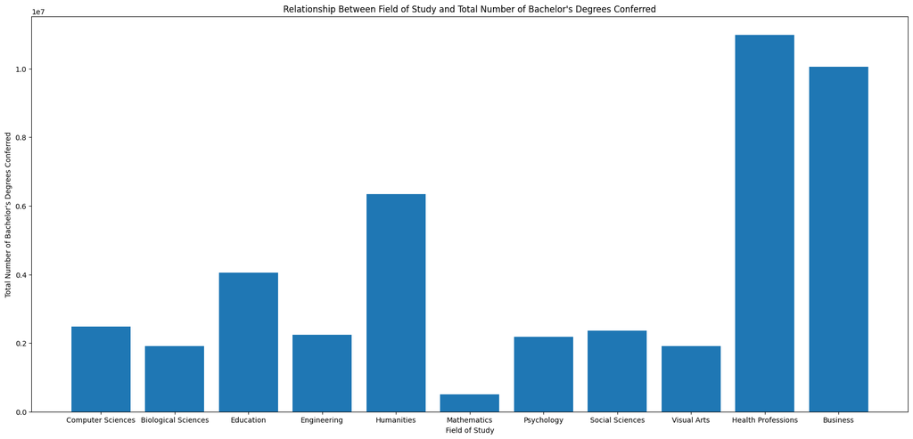

```python
field_of_study = ["Computer Sciences", "Biological Sciences", "Education", "Engineering", "Humanities", "Mathematics", "Psychology", "Social Sciences", "Visual Arts", "Health Professions", "Business"]
total_degrees = [sum(computer_sciences["Total"]), sum(biological_sciences["Total"]), sum(education["Total"]), sum(engineering["Total"]), sum(humanities["Total"]), sum(mathematics["Total"]), sum(psychology["Total"]), sum(social_sciences["Total"]), sum(visual_arts["Total"]), sum(health_professions["Total"]), sum(business["Total"])]
fig, ax = plt.subplots(figsize=(22, 10))
ax.bar(field_of_study, total_degrees)
ax.set_xlabel("Field of Study")
ax.set_ylabel("Total Number of Bachelor's Degrees Conferred")
ax.set_title("Relationship Between Field of Study and Total Number of Bachelor's Degrees Conferred")
plt.show()
```

#### **Conclusion From Bar Plot Visualization**

Based on the bar graph, Health Professions is the most popular field of study followed by Business among undergraduate students and Computer Sciences is far behind. Therefore, the popularity of Computer Sciences is not the same across the nation like it is at the University of Maryland.

### **Statistical Method #2: Pearson and Spearman Correlation Tests**

Although we have concluded Computer Sciences is not the most popular field of study, we now want to test if there is a correlation between Computer Sciences and other fields of study to determine if there has been any growth or decline in assoication with other fields. The [Pearson](https://www.scribbr.com/statistics/pearson-correlation-coefficient/) and [Spearman](https://statistics.laerd.com/statistical-guides/spearmans-rank-order-correlation-statistical-guide.php) correlation tests are useful here since they are used to measure the relationship between variables. After applying the test on two variables, a positive result implies a positive correlation and a negative result implies a negative correlation. In addition, the further away the result is from 0 (i.e. 1 or -1) the stronger the correlation and vice versa.

```python
# modified df to only include the fields of study we are interested in and their total values for correlation tests
mod_df = pd.DataFrame({"Computer Sciences": computer_sciences["Total"].tolist(), "Biological Sciences": biological_sciences["Total"].tolist(), "Education": education["Total"].tolist(), "Engineering": engineering["Total"].tolist(), "Humanities": humanities["Total"].tolist(), "Mathematics": mathematics["Total"].tolist(), "Psychology": psychology["Total"].tolist(), "Social Sciences": social_sciences["Total"].tolist(), "Visual Arts": visual_arts["Total"].tolist(), "Health Professions": health_professions["Total"].tolist(), "Business": business["Total"].tolist()})
mod_df
```

|  | Computer Sciences | Biological Sciences | Education | Engineering | Humanities | Mathematics | Psychology | Social Sciences | Visual Arts | Health Professions | Business |
| --- | --- | --- | --- | --- | --- | --- | --- | --- | --- | --- | --- |
| 0 | 124601 | 113137 | 352588 | 128254 | 383877 | 26601 | 137574 | 176718 | 145389 | 785803 | 736595 |
| 1 | 134340 | 120785 | 347457 | 135664 | 422109 | 28603 | 148771 | 180557 | 151113 | 805191 | 749506 |
| 2 | 140655 | 127217 | 327669 | 141555 | 428956 | 31393 | 156603 | 181938 | 153519 | 814238 | 737199 |
| 3 | 150136 | 133077 | 313525 | 151012 | 442315 | 32749 | 161521 | 181733 | 152471 | 824102 | 737953 |
| 4 | 161625 | 138930 | 297979 | 161428 | 459710 | 34412 | 161910 | 179294 | 152083 | 832675 | 748867 |
| 5 | 171299 | 144540 | 293470 | 176494 | 485170 | 36616 | 164467 | 177387 | 143265 | 838038 | 757211 |
| 6 | 188082 | 148292 | 293886 | 187224 | 501549 | 39045 | 164967 | 178114 | 142877 | 846738 | 767246 |
| 7 | 199329 | 152323 | 294842 | 193765 | 514743 | 42582 | 166065 | 182131 | 144343 | 846348 | 785461 |
| 8 | 210028 | 157100 | 296108 | 196979 | 546788 | 44846 | 169578 | 185687 | 146180 | 870031 | 805638 |
| 9 | 226264 | 163612 | 299646 | 196433 | 558119 | 47072 | 175742 | 187876 | 148453 | 850160 | 803395 |
| 10 | 242460 | 171547 | 316328 | 194022 | 555281 | 47396 | 187527 | 188674 | 142463 | 888355 | 823316 |
| 11 | 249197 | 173787 | 316566 | 188089 | 536092 | 45495 | 193425 | 179495 | 143313 | 894050 | 806604 |
| 12 | 282604 | 174692 | 304848 | 194536 | 510422 | 45206 | 200390 | 174350 | 142964 | 881691 | 791675 |

#### **Pearson Correlation**

```python
# perform Pearson correlation for computer sciences
pearson_matrix = mod_df.corr(method='pearson')
pearson_corr = pearson_matrix["Computer Sciences"].sort_values(ascending=False)
display(pearson_corr)
```

|  | Computer Sciences |
| --- | --- |
| Computer Sciences | 1.000000 |
| Biological Sciences | 0.975713 |
| Psychology | 0.961263 |
| Health Professions | 0.935792 |
| Mathematics | 0.928784 |
| Business | 0.880928 |
| Engineering | 0.868120 |
| Humanities | 0.852704 |
| Social Sciences | 0.158372 |
| Education | -0.487240 |
| Visual Arts | -0.626794 |

**dtype:** float64

#### **Heatmap Visualization for Pearson Correlation**

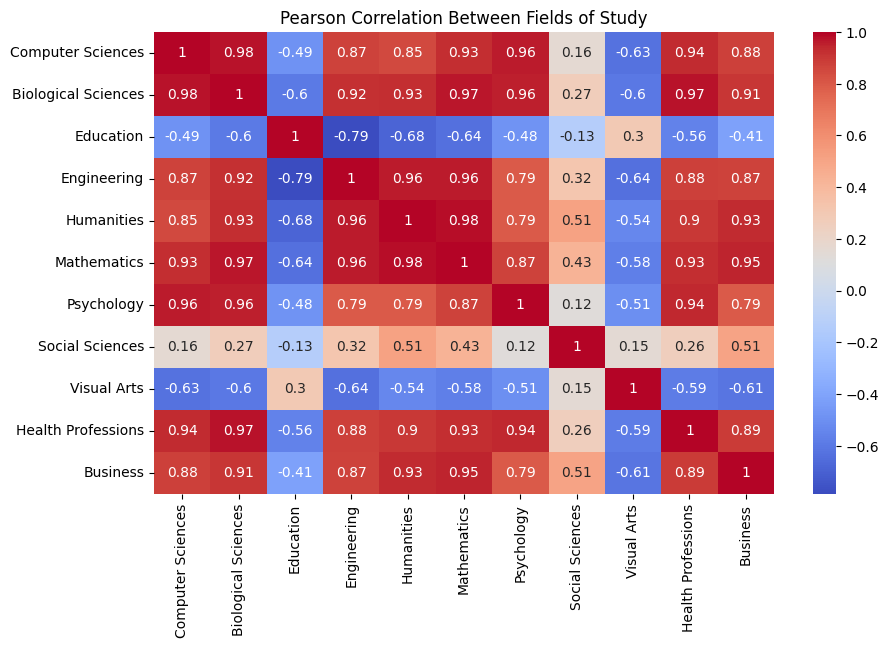

```python
# visualize results from Pearson correlation
plt.figure(figsize=(10, 6))
sns.heatmap(pearson_matrix, annot=True, cmap="coolwarm")
plt.title("Pearson Correlation Between Fields of Study")
plt.show()
```

#### **Spearman Correlation**

```python
# perform Spearman correlation for computer sciences
spearman_matrix = mod_df.corr(method="spearman")
spearman_corr = spearman_matrix["Computer Sciences"].sort_values(ascending=False)
display(spearman_corr)
```

|  | Computer Sciences |
| --- | --- |
| Computer Sciences | 1.000000 |
| Biological Sciences | 1.000000 |
| Psychology | 1.000000 |
| Health Professions | 0.972527 |
| Mathematics | 0.950549 |
| Business | 0.901099 |
| Engineering | 0.884615 |
| Humanities | 0.879121 |
| Social Sciences | 0.197802 |
| Education | -0.329670 |
| Visual Arts | -0.604396 |

**dtype:** float64

#### **Heatmap Visualization for Spearman Correlation**

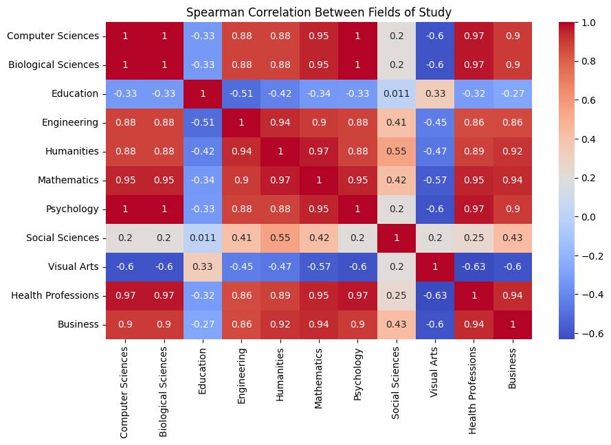

```python
# visualize the results of Spearman correlation
plt.figure(figsize=(10, 6))
sns.heatmap(spearman_matrix, annot=True, cmap="coolwarm")
plt.title("Spearman Correlation Between Fields of Study")
plt.show()
```

#### **Conclusion From Pearson/Spearman Correlation Tests And Visualizations**

```python
# Display the results of both correlation tests
correlation_df = pd.DataFrame({
    "Pearson": pearson_corr,
    "Spearman": spearman_corr
})
correlation_df = correlation_df.sort_values(by="Pearson", ascending=False)
display(correlation_df)
```

|  | Pearson | Spearman |
| --- | --- | --- |
| Computer Sciences | 1.000000 | 1.000000 |
| Biological Sciences | 0.975713 | 1.000000 |
| Psychology | 0.961263 | 1.000000 |
| Health Professions | 0.935792 | 0.972527 |
| Mathematics | 0.928784 | 0.950549 |
| Business | 0.880928 | 0.901099 |
| Engineering | 0.868120 | 0.884615 |
| Humanities | 0.852704 | 0.879121 |
| Social Sciences | 0.158372 | 0.197802 |
| Education | -0.487240 | -0.329670 |
| Visual Arts | -0.626794 | -0.604396 |

- The Pearson and Spearman correlation coefficients yield similar results.
- The following fields have a **strong positive correlation** with Computer Sciences. This means there has been growth:
  - Biological Sciences
  - Psychology
  - Health Professions
  - Mathematics
  - Business
  - Engineering
  - Humanities
- The following field has a **weak positive correlation** with Computer Sciences. This means there has been very minimal growth:
  - Social Sciences
- The following fields have a **moderate to strong negative correlation** with Computer Sciences. This means there has beeen some decline:
  - Education
  - Visual Arts

### **Statistical Method #3: Hypothesis Testing with T-Test**

#### **T-Tests**

We will conclude our exploratory analysis with another hypothesis testing with [t-test](https://www.scribbr.com/statistics/t-test/) to understand the role of gender in the fields of study, more specifically Computer Sciences. We are using t-test to compare the means of each group which will allow us to determine if there is a difference in the number of degrees conferred to men and women.

The null and alternate hypotheses:

- HO: There is no difference in the number of degrees conferred to women and men by postsecondary institutions in various fields of study.
- HA: The is a difference in the number of degrees conferred to women and men by postsecondary institutions in various fields of study.

```python
from scipy import stats

# ttest for computer sciences
res = stats.ttest_ind(computer_sciences["Women"], computer_sciences["Men"])
print(f"Field of Study: Computer Sciences, p-value: {res.pvalue}")

# ttest for biological sciences
res = stats.ttest_ind(biological_sciences["Women"], biological_sciences["Men"])
print(f"Field of Study: Biological Sciences, p-value: {res.pvalue}")

# ttest for education
res = stats.ttest_ind(education["Women"], education["Men"])
print(f"Field of Study: Education, p-value: {res.pvalue}")

# ttest for engineering
res = stats.ttest_ind(engineering["Women"], engineering["Men"])
print(f"Field of Study: Engineering, p-value: {res.pvalue}")

# ttest for humanities
res = stats.ttest_ind(humanities["Women"], humanities["Men"])
print(f"Field of Study: Humanities, p-value: {res.pvalue}")

# test for mathematics
res = stats.ttest_ind(mathematics["Women"], mathematics["Men"])
print(f"Field of Study: Mathematics, p-value: {res.pvalue}")

# ttest for psychology
res = stats.ttest_ind(psychology["Women"], psychology["Men"])
print(f"Field of Study: Psychology, p-value: {res.pvalue}")

# ttest for social sciences
res = stats.ttest_ind(social_sciences["Women"], social_sciences["Men"])
print(f"Field of Study: Social Sciences, p-value: {res.pvalue}")

# ttest for visual arts
res = stats.ttest_ind(visual_arts["Women"], visual_arts["Men"])
print(f"Field of Study: Visual Arts, p-value: {res.pvalue}")

# ttest for health professions
res = stats.ttest_ind(health_professions["Women"], health_professions["Men"])
print(f"Field of Study: Health Professions, p-value: {res.pvalue}")

# ttest for business
res = stats.ttest_ind(business["Women"], business["Men"])
print(f"Field of Study: Business, p-value: {res.pvalue}")
```

```
Field of Study: Computer Sciences, p-value: 1.7029325624779213e-09
Field of Study: Biological Sciences, p-value: 2.021981723039644e-07
Field of Study: Education, p-value: 1.3597588258181654e-23
Field of Study: Engineering, p-value: 3.930755099792566e-15
Field of Study: Humanities, p-value: 3.2350168503373173e-10
Field of Study: Mathematics, p-value: 3.6100833096461584e-05
Field of Study: Psychology, p-value: 2.0747099849153265e-17
Field of Study: Social Sciences, p-value: 3.5397746489229785e-09
Field of Study: Visual Arts, p-value: 2.481390191814681e-21
Field of Study: Health Professions, p-value: 6.118503946479027e-29
Field of Study: Business, p-value: 0.004984558817104674
```

#### **Conclusion From T-Tests**

Reject the null hypothesis, because the p-value for all fields of study including Computer Sciences is less than the significance level, 0.05, which concludes that the number of degrees conferred to men and women is significantly different.

#### **Line Plot Visualizations**

We will visualize the data for each field of study to see the difference in the number of degrees conferred to women and men, especially for Computer Sciences.

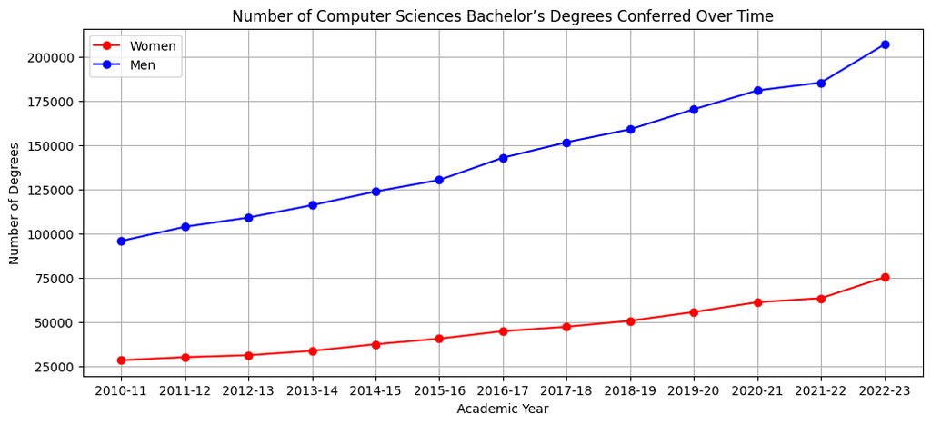

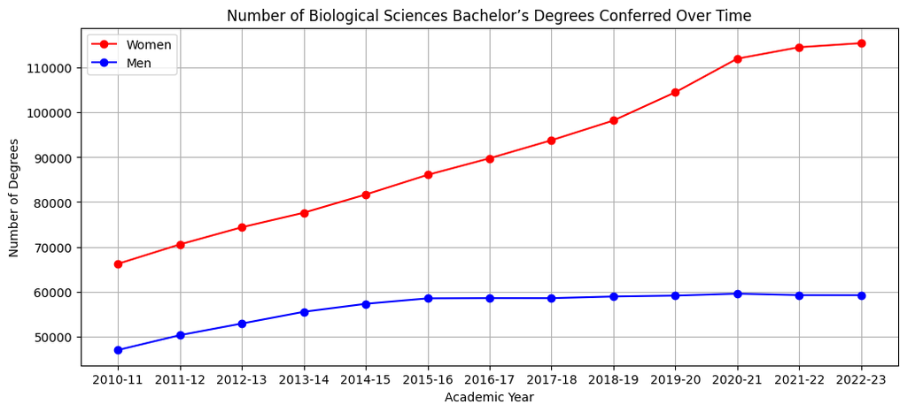

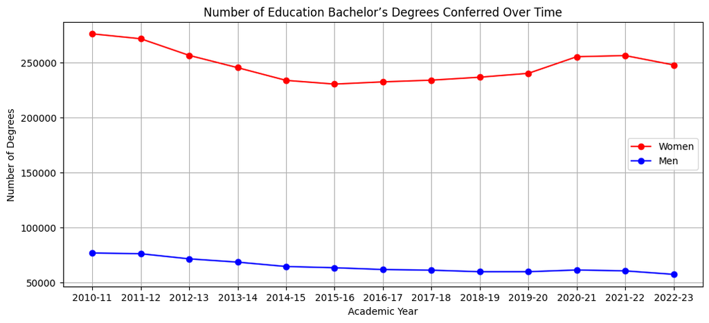

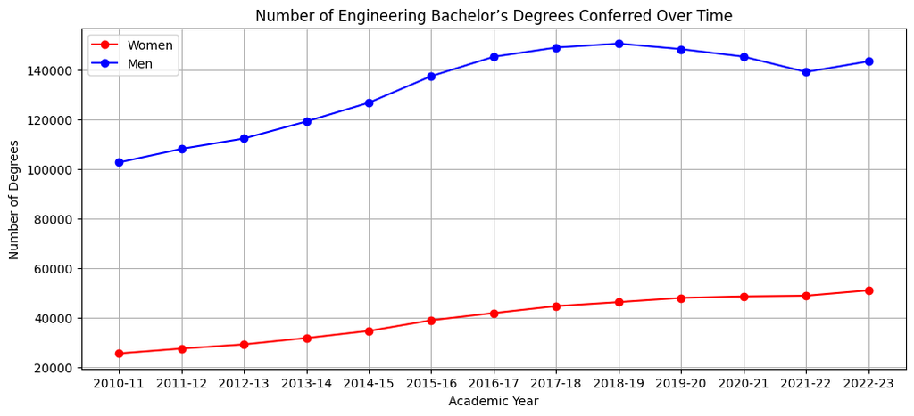

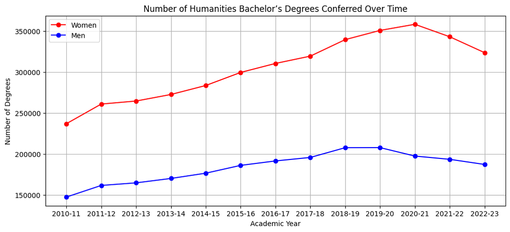

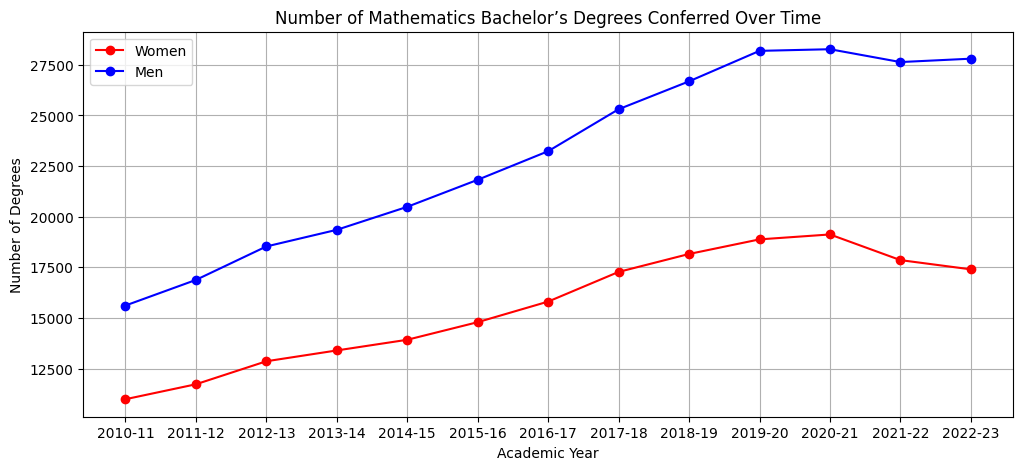

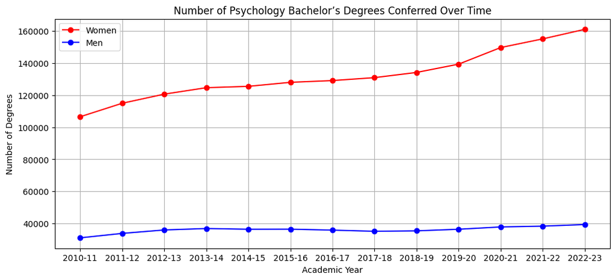

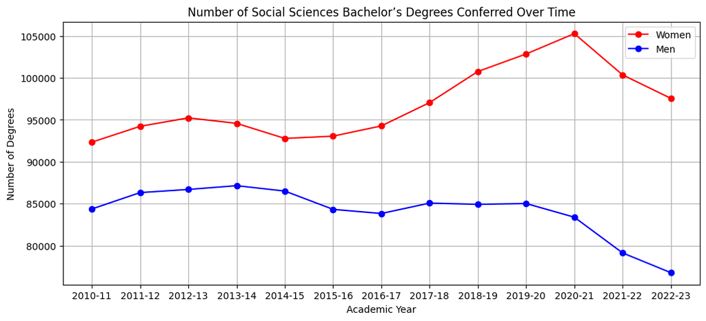

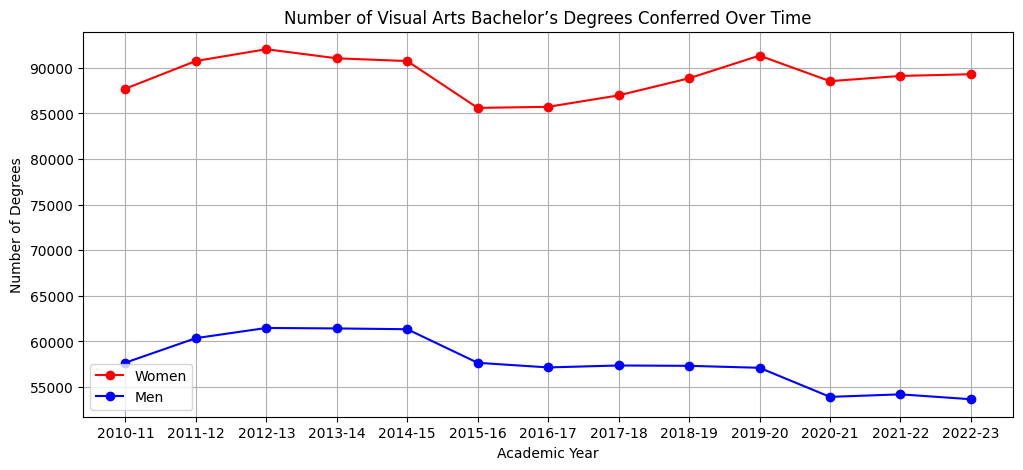

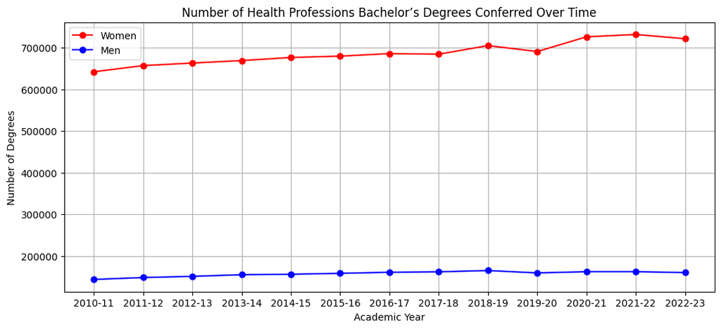

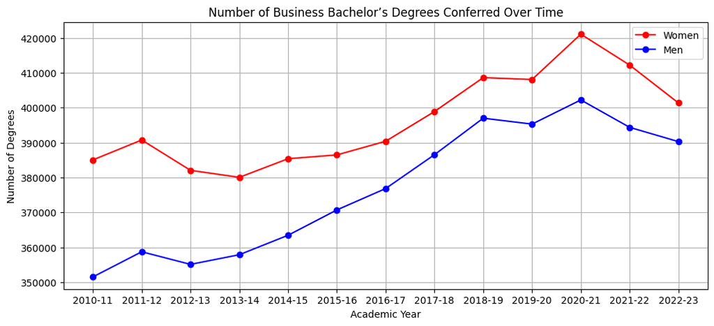

```python
# line plot for computer sciences
plt.figure(figsize=(12, 5))
plt.plot(computer_sciences["Academic Year"], computer_sciences["Women"], label="Women", marker="o", color="red")
plt.plot(computer_sciences["Academic Year"], computer_sciences["Men"], label="Men", marker="o", color="blue")
plt.title("Number of Computer Sciences Bachelor’s Degrees Conferred Over Time")
plt.xlabel("Academic Year")
plt.ylabel("Number of Degrees")
plt.legend()
plt.grid(True)
plt.show()

# line plot for biological sciences
plt.figure(figsize=(12, 5))
plt.plot(biological_sciences["Academic Year"], biological_sciences["Women"], label="Women", marker="o", color="red")
plt.plot(biological_sciences["Academic Year"], biological_sciences["Men"], label="Men", marker="o", color="blue")
plt.title("Number of Biological Sciences Bachelor’s Degrees Conferred Over Time")
plt.xlabel("Academic Year")
plt.ylabel("Number of Degrees")
plt.legend()
plt.grid(True)
plt.show()

# line plot for education
plt.figure(figsize=(12, 5))
plt.plot(education["Academic Year"], education["Women"], label="Women", marker="o", color="red")
plt.plot(education["Academic Year"], education["Men"], label="Men", marker="o", color="blue")
plt.title("Number of Education Bachelor’s Degrees Conferred Over Time")
plt.xlabel("Academic Year")
plt.ylabel("Number of Degrees")
plt.legend()
plt.grid(True)
plt.show()

# line plot for engineering
plt.figure(figsize=(12, 5))
plt.plot(engineering["Academic Year"], engineering["Women"], label="Women", marker="o", color="red")
plt.plot(engineering["Academic Year"], engineering["Men"], label="Men", marker="o", color="blue")
plt.title("Number of Engineering Bachelor’s Degrees Conferred Over Time")
plt.xlabel("Academic Year")
plt.ylabel("Number of Degrees")
plt.legend()
plt.grid(True)
plt.show()

# line plot for humanities
plt.figure(figsize=(12, 5))
plt.plot(humanities["Academic Year"], humanities["Women"], label="Women", marker="o", color="red")
plt.plot(humanities["Academic Year"], humanities["Men"], label="Men", marker="o", color="blue")
plt.title("Number of Humanities Bachelor’s Degrees Conferred Over Time")
plt.xlabel("Academic Year")
plt.ylabel("Number of Degrees")
plt.legend()
plt.grid(True)
plt.show()

# line plot for mathematics
plt.figure(figsize=(12, 5))
plt.plot(mathematics["Academic Year"], mathematics["Women"], label="Women", marker="o", color="red")
plt.plot(mathematics["Academic Year"], mathematics["Men"], label="Men", marker="o", color="blue")
plt.title("Number of Mathematics Bachelor’s Degrees Conferred Over Time")
plt.xlabel("Academic Year")
plt.ylabel("Number of Degrees")
plt.legend()
plt.grid(True)
plt.show()

# line plot for psychology
plt.figure(figsize=(12, 5))
plt.plot(psychology["Academic Year"], psychology["Women"], label="Women", marker="o", color="red")
plt.plot(psychology["Academic Year"], psychology["Men"], label="Men", marker="o", color="blue")
plt.title("Number of Psychology Bachelor’s Degrees Conferred Over Time")
plt.xlabel("Academic Year")
plt.ylabel("Number of Degrees")
plt.legend()
plt.grid(True)
plt.show()

# line plot for social sciences
plt.figure(figsize=(12, 5))
plt.plot(social_sciences["Academic Year"], social_sciences["Women"], label="Women", marker="o", color="red")
plt.plot(social_sciences["Academic Year"], social_sciences["Men"], label="Men", marker="o", color="blue")
plt.title("Number of Social Sciences Bachelor’s Degrees Conferred Over Time")
plt.xlabel("Academic Year")
plt.ylabel("Number of Degrees")
plt.legend()
plt.grid(True)
plt.show()

# line plot for visual arts
plt.figure(figsize=(12, 5))
plt.plot(visual_arts["Academic Year"], visual_arts["Women"], label="Women", marker="o", color="red")
plt.plot(visual_arts["Academic Year"], visual_arts["Men"], label="Men", marker="o", color="blue")
plt.title("Number of Visual Arts Bachelor’s Degrees Conferred Over Time")
plt.xlabel("Academic Year")
plt.ylabel("Number of Degrees")
plt.legend()
plt.grid(True)
plt.show()

# line plot for health professions
plt.figure(figsize=(12, 5))
plt.plot(health_professions["Academic Year"], health_professions["Women"], label="Women", marker="o", color="red")
plt.plot(health_professions["Academic Year"], health_professions["Men"], label="Men", marker="o", color="blue")
plt.title("Number of Health Professions Bachelor’s Degrees Conferred Over Time")
plt.xlabel("Academic Year")
plt.ylabel("Number of Degrees")
plt.legend()
plt.grid(True)
plt.show()

# line plot for business
plt.figure(figsize=(12, 5))
plt.plot(business["Academic Year"], business["Women"], label="Women", marker="o", color="red")
plt.plot(business["Academic Year"], business["Men"], label="Men", marker="o", color="blue")
plt.title("Number of Business Bachelor’s Degrees Conferred Over Time")
plt.xlabel("Academic Year")
plt.ylabel("Number of Degrees")
plt.legend()
plt.grid(True)
plt.show()
```

#### **Conclusion from Line Plot Visualizations**

- In most non-STEM fields like Education, Humanities, Psychology, Social Sciences, Visual Arts, Health Professions, and Business and one STEM field, Biological Sciences, the number of degrees conferred to women is greater than men.
- In most STEM fields like Computer Sciences, Engineering, and Mathematics, the number of degrees conferred to men is greater than women.
- For Computer Sciences, men significantly dominate the field. However, there has been a steady increase in the number of women majoring in Computer Sciences.

## **Primary Analysis**

Based on the results from our exploration, we will now use [K-Means clustering](https://www.ibm.com/think/topics/k-means-clustering) as our machine learning technique. We will perform clustering on the total number of degrees conferred to students by postsecondary institutions to group each field of study by its popularity. From our exploratory data analysis, even though we know Computer Science is not the most popular program, we now want to know where it stands among other programs.

### **K-Means Clustering by Total Number of Degrees Conferred**

In this analysis, we will consider all the fields of study unlike the selected few chosen for the exploratory analysis.

```python
# total number of degrees conferred across all the academic years
mod_df = df.groupby("CIP Title")["Total"].sum()
X = pd.DataFrame(mod_df)
X
```

| CIP Title | Total |
| --- | --- |
| Agricultural/Animal/Plant/Veterinary Science and Related Fields | 192761 |
| Agriculture, Agriculture Operations and Related Sciences | 297798 |
| Architecture and Related Services | 236317 |
| Area, Ethnic, Cultural, Gender, and Group Studies | 158582 |
| Biological and Biomedical Sciences | 1919039 |
| Business, Management, Marketing, and Related Support Services | 10050666 |
| Communication, Journalism, and Related Programs | 1417482 |
| Communications Technologies/Technicians and Support Services | 174727 |
| Computer and Information Sciences and Support Services | 2480620 |
| Construction Trades | 344889 |
| Culinary, Entertainment, and Personal Services | 137915 |
| Education | 4054912 |
| Engineering | 2245455 |
| Engineering Technologies and Engineering-related Fields | 746459 |
| Engineering/Engineering-related Technologies/Technicians | 314615 |
| English Language and Literature/Letters | 751701 |
| Family and Consumer Sciences/Human Sciences | 705124 |
| Foreign Languages, Literatures, and Linguistics | 358920 |
| Health Professions and Related Programs | 10977420 |
| History | 432880 |
| Homeland Security, Law Enforcement, Firefighting and Related Protective Services | 531545 |
| Homeland Security, Law Enforcement, Firefighting, and Related Protective Service | 1288650 |
| Legal Professions and Studies | 860058 |
| Liberal Arts and Sciences, General Studies and Humanities | 6345131 |
| Library Science | 87253 |
| Mathematics and Statistics | 502016 |
| Mechanic and Repair Technologies/Technicians | 1033829 |
| Military Technologies and Applied Sciences | 31450 |
| Multi/Interdisciplinary Studies | 1278984 |
| Natural Resources and Conservation | 338743 |
| Parks, Recreation, Leisure and Fitness Studies | 552662 |
| Parks, Recreation, Leisure, Fitness, and Kinesiology | 284114 |
| Personal and Culinary Services | 405927 |
| Philosophy and Religious Studies | 199770 |
| Physical Sciences | 613510 |
| Precision Production | 501895 |
| Psychology | 2188540 |
| Public Administration and Social Service Professions | 1197966 |
| Science Technologies/Technicians | 74685 |
| Social Sciences | 2353954 |
| Theology and Religious Vocations | 351782 |
| Transportation and Materials Moving | 280654 |
| Visual and Performing Arts | 1908433 |

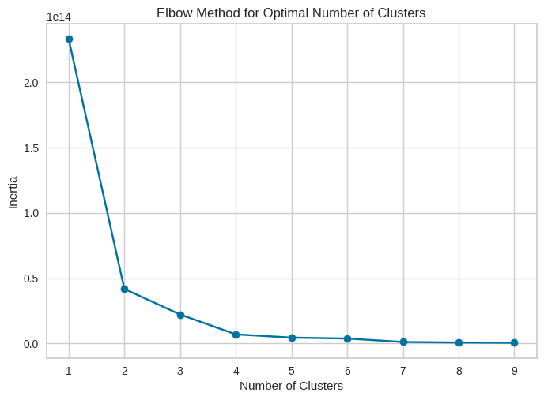

```python
# apply the elbow method to determine the number of clusters
state = 42
inertias = []
K = range(1, 10)

for k in K:
    # apply kmeans clustering
    kmeans = KMeans(n_clusters=k, random_state=state)
    kmeans.fit(X)
    inertias.append(kmeans.inertia_)

# plot the result to see the optimal number
plt.plot(K, inertias, marker="o")
plt.xlabel("Number of Clusters")
plt.ylabel("Inertia")
plt.title("Elbow Method for Optimal Number of Clusters")
plt.show()
```

The optimal number of clusters appear to be 2.

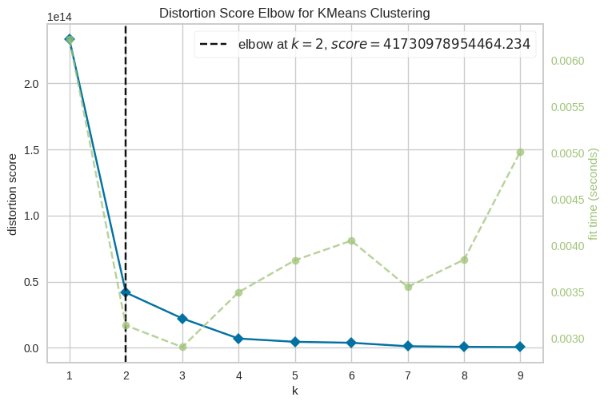

```python
# use the KElbowVisualizer from the yellowbrick library to verify result
from yellowbrick.cluster import SilhouetteVisualizer
from yellowbrick.cluster import KElbowVisualizer
model = KMeans(random_state=state)
visualizer = KElbowVisualizer(model, k=K)
visualizer.fit(X)
visualizer.show()
```

```python
# the optimal number of clusters is 2
k_cluster = 2
```

```python
# apply standard scaler to normalize the data
scaler = StandardScaler()
X_scaled = scaler.fit_transform(X[["Total"]])
```

```python
# apply kmeans clustering and return the cluster labels
kmeans = KMeans(n_clusters=k_cluster, random_state=state)
X["Cluster"] = kmeans.fit_predict(X_scaled)
```

## **Visualization**

We will now visualize the results from K-Means clustering to gain insights. Since there is only one feature used in the analysis, total number of degrees, a strip plot and a bar chart are effective visualizations for the result.

### **Strip Plot**

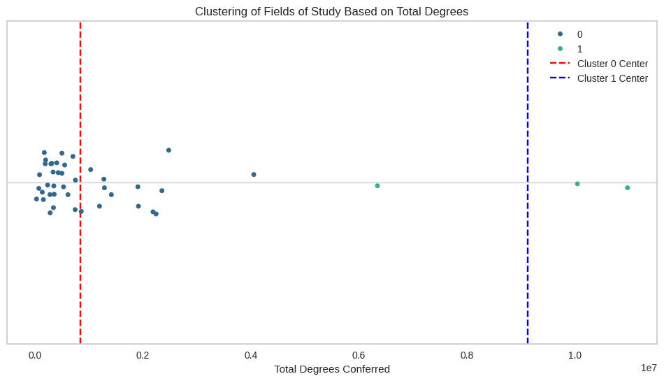

```python
# create a strip plot to visualize the clusters
plt.figure(figsize=(12, 6))
sns.stripplot(data=X, x="Total", hue="Cluster", jitter=True, palette="viridis")
plt.axvline(x=scaler.inverse_transform(kmeans.cluster_centers_)[0][0], color='red', linestyle='--', label="Cluster 0 Center")
plt.axvline(x=scaler.inverse_transform(kmeans.cluster_centers_)[1][0], color='blue', linestyle='--', label="Cluster 1 Center")
plt.xlabel("Total Degrees Conferred")
plt.title("Clustering of Fields of Study Based on Total Degrees")
plt.legend()
plt.grid()
plt.show()
```

### **Strip Plot Interpretations**

- There is a clear divide between the two clusters.
- Data points that are not popular are clustered to the far left, shown as blue dots and labeled as 0.
- Data points that are popular are clustered to the far right, show as green dots and labeled as 1.
- Majority of the data points are in Cluster 0, the not popular cluster, while only 3 observable data points are in Cluster 1, the popular cluster.

### **Bar Chart**

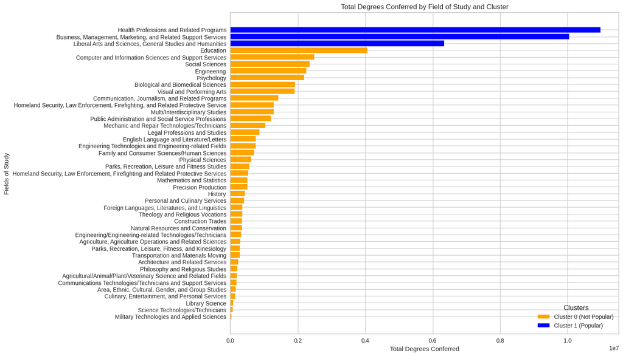

```python
# create a bar chart to visualize the popularity of each field of study
from matplotlib.patches import Patch
X_sorted = X.sort_values("Total").reset_index()
plt.figure(figsize=(12, 10))
plt.barh(X_sorted["CIP Title"], X_sorted["Total"], color=X_sorted["Cluster"].map({0: "orange", 1: "blue"}))
plt.xlabel("Total Degrees Conferred")
plt.ylabel("Fields of Study")
plt.title("Total Degrees Conferred by Field of Study and Cluster")
legend_handles = [
    Patch(color="orange", label="Cluster 0 (Not Popular)"),
    Patch(color="blue", label="Cluster 1 (Popular)")
]
plt.legend(handles=legend_handles, title="Clusters")
plt.show()
```

## **Insights and Conclusions**

The goal of our project was to analyze the trends in bachelor’s degrees conferred to undergraduate students by postsecondary institutions across the United States with the emphasis on Computer Science. We wanted to share the trends with uninformed readers and either confirm their theories or share new findings with informed readers. Regarding Computer Science, we wanted to answer questions like is Computer Science the most popular field of study among undergraduate students? Is Computer Science a popular field of study among women in comparison to men? We wanted to answer those questions because based on our time at the University of Maryland, Computer Science has become the most popular choice of major among students in recent years. The demand has increased so much that it has become a limited enrollment program. We wanted to analyze the data to determine whether this is true across the United States and consider what could be the reason behind this trend.

Our exploratory data analysis showed us that Computer Science is not the most post popular field of study among students across the United States as indicated by the online media. Instead, the popular choices are programs related to health professions, business, liberal arts and humanities, etc. However, based on our correlation tests, we confirmed that there is growth in Computer Science in correlation to some other fields. Even among women, it is not a popular field of study in comparison to men. However, based on our t-test analysis and visualizations, we confirmed that there is an upward trend. While currently there is a big difference, women are interested in studying Computer Science. Our primary analysis with K-Means clustering basically confirmed the results from the exploratory analysis. The top three pouplar fields are programs related to health professions, business, and liberal arts and humanities. However, in the not popular cluster, Computer Science is second in its popularity.